# **POTATO DISEASE CLASSIFICATION USING A CONVOLUTIONAL NEURAL NETWORK**

## **1. Introduction**

Farmers growing potatoes may face or are facing loss of income yearly because of various diseases plaguing their plants. The most common diseases which can affect potatoes are:

**1. Early Blight**

Early blight is primarily a disease of stressed or senecing plants. Symptoms appear on the oldest foliage. Affected leaves develop circular to angular dark brown lesions (3-4mm) in diameter. Concentric rings often form in lesions to produce characteristic target-board effect. Severely infected leaves turn yellow and drop.

[figure not shown]

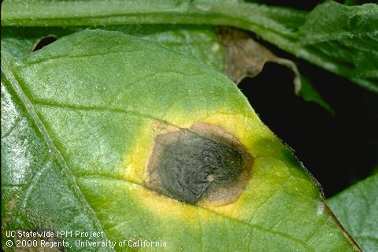

Infected tubers show a brown, corky dry rot.

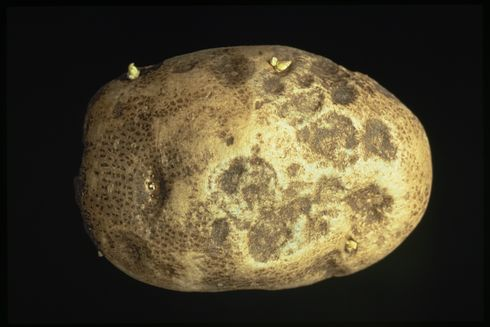

Infection occurs when spores of fungus come in contact with leaves when sufficient moisture is present. Spore germination and infection are favoured by warm weather and wet conditions from dew, rain or sprinkler irrigation. Alternatively, wet and dry periods with relatively dry, windy conditions favor spore dispersion and disease spread. Tubers can be infected as they are lifted through the soil during harvesting. If sufficient moisture is present, spores germinate and infect the tubers.

**2. Late blight**

Late blight is caused by a fungal-like oomycete pathogen, Phytophthora infestants. Late blight of the potato is identified by blackish or brown lesions on leaves and stems that maybe small at first and appear water soaked or have chlorotic borders but expand rapidly and the entire leaf becomes necrotic.

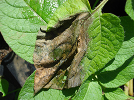

In humid conditions, Phytophthora infestants produce sporangia and sporangiophores on the surface of infected tissue and the resulting white sporulation can be seen at the margins of the lesions on the lower surfaces of leaves. As many lesions accumulate, the entire plant can be destroyed in a matter of days after the first lesions are observed if the approprite fungicide applications are not used. The image below shows tubers infected with late blight.

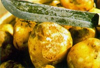

If farmers can detect these diseases early and apply appropriate treatment, a lot of plants can be saved and also prevent economic loss. The treatments for early and late blight are different hence it is important to be able to distinguish the two. The dataset used for this project was downloaded from https://www.kaggle.com/datasets/arjuntejaswi/plant-village

## **2. Downloading the data into Tensorflow and data cleaning**

### **i.Importing relevant libraries**

```python
import tensorflow as tf
from tensorflow.keras import models, layers,activations
import matplotlib.pyplot as plt
import numpy as np
```

### **ii. Downloading the data into tensorflow**

```python
image_size = 256
batch_size = 32
dataset = tf.keras.preprocessing.image_dataset_from_directory(
            "C:\\Users\\mfaro\\Documents\\GitHub\\Potato-disease-detection\\training\\PlantVillage",
            shuffle = True,
            image_size = (image_size,image_size),
            batch_size = batch_size
            )
class_names = dataset.class_names
```

```
Found 2152 files belonging to 3 classes.
```

```python
epochs = 50
image_size = 256
batch_size = 32
channels = 3
input_shape = (batch_size,image_size,image_size,channels)
```

### **iii. Visualizing Images**

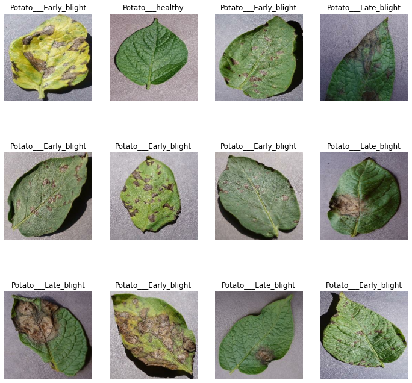

```python
plt.figure(figsize=(12,12))
for image_batch, label_batch in dataset.take(1):
    for i in range(12):
        ax = plt.subplot(3,4,i+1)
        plt.imshow(image_batch[i].numpy().astype("int32"))
        plt.title(class_names[label_batch[i]])
        plt.axis("off")
```

## **3. Splitting the dataset to training,test and validation datasets**

```python
def get_dataset_partitions_tf(ds,train_split=0.8,val_split=0.1,test_split=0.1,shuffle=True,shuffle_size=10000):
    ds_size = len(ds)
    if shuffle:
        ds = ds.shuffle(shuffle_size,seed = 12)
    train_size = int(train_split*ds_size)
    val_size = int(val_split*ds_size)
    train_ds = ds.take(train_size)
    val_ds = ds.skip(train_size).take(val_size)
    test_ds = ds.skip(train_size).skip(val_size)


    return train_ds,val_ds,test_ds
```

```python
train_ds,val_ds,test_ds = get_dataset_partitions_tf(dataset)
```

```python
len(train_ds),len(val_ds),len(test_ds)
```

```
(54, 6, 8)
```

```python
train_ds = train_ds.cache().shuffle(1000).prefetch(buffer_size=tf.data.AUTOTUNE)
val_ds = val_ds.cache().shuffle(1000).prefetch(buffer_size=tf.data.AUTOTUNE)
test_ds = test_ds.cache().shuffle(1000).prefetch(buffer_size=tf.data.AUTOTUNE)
```

## **4. Resizing and scaling the data**

```python
resize_and_rescale = tf.keras.Sequential([
                        tf.keras.layers.experimental.preprocessing.Resizing(image_size,image_size),
                        tf.keras.layers.experimental.preprocessing.Rescaling(1.0/255)
])
```

## **5. Data Augmentation**

```python
data_augmentation = tf.keras.Sequential([
                        layers.experimental.preprocessing.RandomFlip("horizontal_and_vertical"),
                        layers.experimental.preprocessing.RandomRotation(0.2)
])
```

## **6. Model**

```python
model = models.Sequential([
            resize_and_rescale,
            data_augmentation,
            # Convolutional Layers
            layers.Conv2D(32,kernel_size=(3,3),activation = 'relu'),
            layers.MaxPool2D((2,2)),
            layers.Conv2D(64,kernel_size=(3,3),activation = 'relu'),
            layers.MaxPool2D((2,2)),
            layers.Conv2D(64,kernel_size=(3,3),activation = 'relu'),
            layers.MaxPool2D((2,2)),
            layers.Conv2D(64,kernel_size=(3,3),activation = 'relu'),
            layers.MaxPool2D((2,2)),
            layers.Conv2D(64,kernel_size=(3,3),activation = 'relu'),
            layers.MaxPool2D((2,2)),
            layers.Conv2D(64,kernel_size=(3,3),activation = 'relu'),
            layers.MaxPool2D((2,2)),
            # Dense Layers
            layers.Flatten(),
            layers.Dense(64,activation = 'relu'),
            # Output Layer
            layers.Dense(3,activation = 'softmax')
])
model.build(input_shape = input_shape)
model.compile(
                optimizer = 'adam',
                loss = tf.keras.losses.SparseCategoricalCrossentropy(from_logits=False),
                metrics = ["accuracy"])

history = model.fit(train_ds,epochs=epochs,batch_size=batch_size,verbose=1,validation_data=val_ds)
```

## **7. Evaluating the model**

```python
scores = model.evaluate(test_ds)
scores
```

```
[0.02034802734851837, 0.9921875]
```

From the test data, the accuracy of the model is 99%

```python
history.params
```

```
{'verbose': 1, 'epochs': 50, 'steps': 54}
```

```python
history.history.keys()
```

```
dict_keys(['loss', 'accuracy', 'val_loss', 'val_accuracy'])
```

```python
# Gives the accuracy of the model at the end of each epoch
#history.history['accuracy']
```

### **i. Accuracy and Loss plots**

```python
acc = history.history['accuracy']
val_acc = history.history['val_accuracy']
loss = history.history['loss']
val_loss = history.history['val_loss']
```

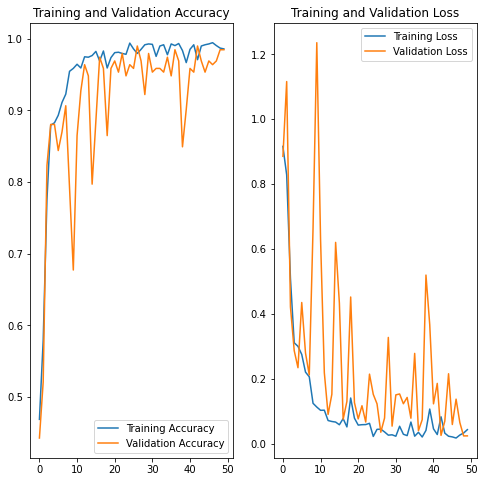

```python
plt.figure(figsize=(8,8))
plt.subplot(1,2,1)
plt.plot(range(epochs),acc,label='Training Accuracy')
plt.plot(range(epochs),val_acc,label='Validation Accuracy')
plt.legend(loc = 'lower right')
plt.title("Training and Validation Accuracy")
plt.subplot(1,2,2)
plt.plot(range(epochs),loss,label='Training Loss')
plt.plot(range(epochs),val_loss,label='Validation Loss')
plt.legend(loc = 'upper right')
plt.title("Training and Validation Loss")
plt.show()
```

### **ii. Predictions**

```python
def predict(model,img):
    img_array = tf.keras.preprocessing.image.img_to_array(images[i].numpy())
    img_array = tf.expand_dims(img_array,0) #Create a batch
    predictions = model.predict(img_array)

    predicted_class = class_names[np.argmax(predictions[0])]
    confidence = round(100*np.max(predictions[0]),2)
    return predicted_class,confidence
```

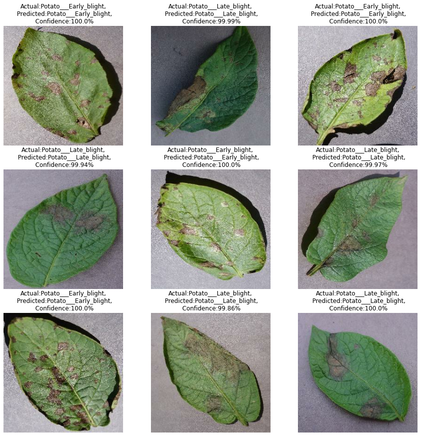

```python
plt.figure(figsize = (15,15))
for images,labels in test_ds.take(1):
    for i in range(9):
        ax = plt.subplot(3,3,i+1)
        plt.imshow(images[i].numpy().astype("int64"))
        predicted_class,confidence=predict(model,images[i].numpy())
        actual_class = class_names[labels[i]]
        plt.title(f"Actual:{actual_class},\n Predicted:{predicted_class},\n Confidence:{confidence}%")
        plt.axis("off")
```

```python
model.save(f"C:/Users/mfaro/Documents/GitHub/Potato-disease-detection/models/{model_version}")
```

```
WARNING:absl:Found untraced functions such as _jit_compiled_convolution_op, _jit_compiled_convolution_op, _jit_compiled_convolution_op, _jit_compiled_convolution_op, _jit_compiled_convolution_op while saving (showing 5 of 6). These functions will not be directly callable after loading.
```

```
INFO:tensorflow:Assets written to: C:/Users/mfaro/Documents/GitHub/Potato-disease-detection/models/1\assets
```

```
INFO:tensorflow:Assets written to: C:/Users/mfaro/Documents/GitHub/Potato-disease-detection/models/1\assets
```

```python
tf.__version__
```

```
'2.9.2'
```